# Assignment 4 - MSCA 31010

Melanie Tran

2/15/2021

**1) Estimate a generalized linear model assuming the response follows a Poisson distribution, the mean response is linked to the linear predictor by a log function. Use the dataset ‘’z1037.poisson-loglink.RData’’ to estimate the parameters in the linear predictor by maximum likelihood estimation.**

```r
load("C:/Users/meltra02/Desktop/MSCA/Quarter 2/31010 - Linear Nonlinear/31010 - Assignment - 4/z1037.poisson-loglink.RData")
library(reshape2)
```

```r
dta <- data.frame(ite=numeric(),b0=numeric(),b1=numeric(),err=numeric(),stringsAsFactors=FALSE)
```

**First, estimate the parameters of the GLM with Poisson response and log link function by modifying the Newton-Raphson algorithm.**

```r
y <- matrix(regdta$y,ncol=1)
X <- matrix(c(regdta$x1,regdta$x2),nrow = 100, ncol=2, byrow = FALSE)

b0 <- c(1,1)
tol <- 1e-5
err <- 1e10
ite <- 0
while (err>tol){

    var.y <- exp(X %*% b0) #based on log link
    W <- diag(as.numeric(var.y),nrow=length(var.y),ncol=length(var.y)) #mu = var.y
    z <-  (X %*% b0)+(y - var.y) *(exp(-X %*% b0)) #updated based on log link

    b1 <- solve(t(X) %*% W %*% X) %*% (t(X) %*% W %*% z)

    err <- max(abs(b1-b0))
    dta <- rbind(dta,data.frame(ite,b0,b1,err,stringsAsFactors=FALSE))

    b0 <- b1
    ite <- ite + 1
}
```

**Compute and show the values for $W$, $z$, $X^TWX$, and $X^TWz$ on the last iteration.**

*$W$ for Poisson - Log link*

```r
W[1:7,1:7]
```

```
##          [,1]     [,2]     [,3]     [,4]     [,5]     [,6]     [,7]
## [1,] 5.075757 0.000000 0.000000 0.000000 0.000000 0.000000 0.000000
## [2,] 0.000000 7.847412 0.000000 0.000000 0.000000 0.000000 0.000000
## [3,] 0.000000 0.000000 9.944768 0.000000 0.000000 0.000000 0.000000
## [4,] 0.000000 0.000000 0.000000 3.633805 0.000000 0.000000 0.000000
## [5,] 0.000000 0.000000 0.000000 0.000000 8.204701 0.000000 0.000000
## [6,] 0.000000 0.000000 0.000000 0.000000 0.000000 8.392069 0.000000
## [7,] 0.000000 0.000000 0.000000 0.000000 0.000000 0.000000 6.110857
```

*$z$ for Poisson - Log link*

```r
head(z)
```

```
##           [,1]
## [1,] 0.8214906
## [2,] 2.3344893
## [3,] 2.6042666
## [4,] 0.8406676
## [5,] 2.2016394
## [6,] 2.1997282
```

*$X^TWX$ for Poisson - Log link*

```r
t(X) %*% W %*% X
```

```
##           [,1]      [,2]
## [1,] 723.00043  58.34483
## [2,]  58.34483 215.15928
```

*$X^TWz$ for Poisson - Log link*

```r
t(X) %*% W %*% z
```

```
##           [,1]
## [1,] 1464.8906
## [2,]  241.7514
```

*$B_1$ and $B_2$ for Poisson - Log link*

```r
b.no <- rep(c(paste0("b_",1),paste0("b_",2)),nrow(dta)/nrow(b0))
dta <- cbind(dta,b.no)
dta <- dta[,c("ite","b.no","b0")]
dta <- dcast(dta,ite~b.no,value.var="b0")
dta
```

```
##   ite      b_1         b_2
## 1   0 1.000000  1.00000000
## 2   1 2.715833 -0.00575441
## 3   2 2.218450  0.30209381
## 4   3 2.014262  0.53705153
## 5   4 1.979704  0.58571269
## 6   5 1.978757  0.58701196
```

**Plot the values of the parameters for every iteration.**

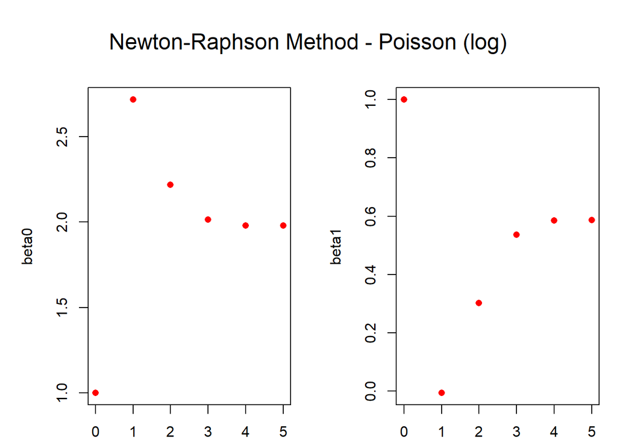

```r
par(mfrow=c(1,2), mar=c(2,5,2,1),oma=c(0,0,3,0))
plot(dta$ite,dta$b_1,ylim=c(min(dta$b_1),max(dta$b_1)),xlab="No of Iterations",ylab="beta0",main="",pch=16,col="red",lty=2)
plot(dta$ite,dta$b_2,ylim=c(min(dta$b_2),max(dta$b_2)),xlab="No of Iterations",ylab="beta1",main="",pch=16,col="red",lty=2)

mtext("Newton-Raphson Method - Poisson (log)",outer=TRUE,cex=1.5)
```

**Estimate the parameters of the Poisson regression with log link function using the glm function in stats R package.**

```r
glm(y~x2,data=regdta,family=poisson(link="log"))$coefficients
```

```
## (Intercept)          x2
##   1.9787560   0.5870129
```

**Do you get the same answer?**

Yes, I got the same answer with an Intercept of 1.979 and $x2$ of 0.587.

**2) Estimate a generalized linear model assuming the response follows a Normal distribution, the mean response is linked to the linear predictor by an identity function. Use the dataset ‘’z1037.normal-identity.RData’’ to estimate the parameters in the linear predictor by maximum likehood estimation.**

```r
load("C:/Users/meltra02/Desktop/MSCA/Quarter 2/31010 - Linear Nonlinear/31010 - Assignment - 4/z1037.normal-identity.RData")
library(reshape2)
```

```r
dta <- data.frame(ite=numeric(),b0=numeric(),b1=numeric(),err=numeric(),stringsAsFactors=FALSE)
```

**First, estimate the parameters of the GLM with Normal response and link identity function by modifying the Newton-Raphson algorithm.**

```r
y <- matrix(regdta$y,ncol=1)
X <- matrix(c(regdta$x1,regdta$x2),nrow = 100, ncol=2, byrow = FALSE)

b0 <- c(1,1)
tol <- 1e-5
err <- 1e10
ite <- 0
while (err>tol){

    var.y <- matrix(1, nrow = length(regdta$x2)) #var is 1 in gaussian
    W <- diag(as.numeric(1/var.y),nrow=length(var.y),ncol=length(var.y))
    z <- y

    b1 <- solve(t(X) %*% W %*% X) %*% (t(X) %*% W %*% z)

    err <- max(abs(b1-b0))
    dta <- rbind(dta,data.frame(ite,b0,b1,err,stringsAsFactors=FALSE))

    b0 <- b1
    ite <- ite + 1
}
```

**Compute and show the values for $W$, $z$, $X^TWX$, and $X^TWz$ on the last iteration.**

*$W$ for Gaussian - Identity link*

```r
W[1:7,1:7]
```

```
##      [,1] [,2] [,3] [,4] [,5] [,6] [,7]
## [1,]    1    0    0    0    0    0    0
## [2,]    0    1    0    0    0    0    0
## [3,]    0    0    1    0    0    0    0
## [4,]    0    0    0    1    0    0    0
## [5,]    0    0    0    0    1    0    0
## [6,]    0    0    0    0    0    1    0
## [7,]    0    0    0    0    0    0    1
```

*$z$ for Gaussian - Identity link*

```r
head(z)
```

```
##           [,1]
## [1,] -1.491335
## [2,]  1.897006
## [3,]  2.395396
## [4,] -1.227311
## [5,]  1.560006
## [6,]  1.570360
```

*$X^TWX$ for Gaussian - Identity link*

```r
t(X) %*% W %*% X
```

```
##            [,1]      [,2]
## [1,] 100.000000 -7.838087
## [2,]  -7.838087 25.582899
```

*$X^TWz$ for Gaussian - Identity link*

```r
t(X) %*% W %*% z
```

```
##          [,1]
## [1,] 87.19362
## [2,] 15.31660
```

*$B_1$ and $B_2$ for Gaussian - Identity link*

```r
b.no <- rep(c(paste0("b_",1),paste0("b_",2)),nrow(dta)/nrow(b0))
dta <- cbind(dta,b.no)
dta <- dta[,c("ite","b.no","b0")]
dta <- dcast(dta,ite~b.no,value.var="b0")
dta
```

```
##   ite       b_1       b_2
## 1   0 1.0000000 1.0000000
## 2   1 0.9414721 0.8871529
```

**Plot the values of the parameters for every iteration.**

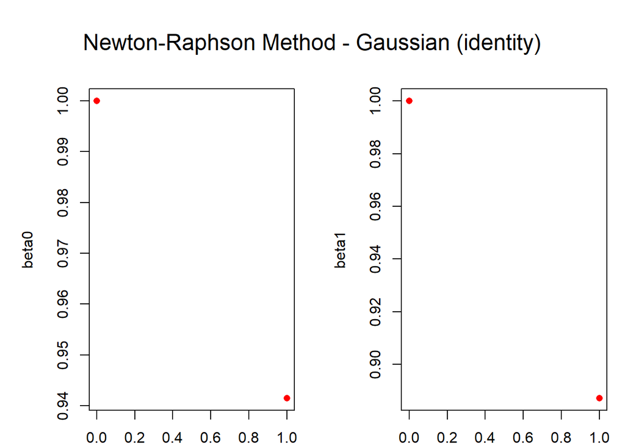

```r
par(mfrow=c(1,2), mar=c(2,5,2,1),oma=c(0,0,3,0))
plot(dta$ite,dta$b_1,ylim=c(min(dta$b_1),max(dta$b_1)),xlab="No of Iterations",ylab="beta0",main="",pch=16,col="red",lty=2)
plot(dta$ite,dta$b_2,ylim=c(min(dta$b_2),max(dta$b_2)),xlab="No of Iterations",ylab="beta1",main="",pch=16,col="red",lty=2)

mtext("Newton-Raphson Method - Gaussian (identity)",outer=TRUE,cex=1.5)
```

**Estimate the parameters of the Gaussian regression with identity link function using the glm function in stats R package.**

```r
glm(y~x2,data=regdta,family=gaussian(link="identity"))$coefficients
```

```
## (Intercept)          x2
##   0.9414721   0.8871529
```

**Do you get the same answer?**

Yes, I got the same answer with an Intercept of 0.941 and $x2$ of 0.887.

**State the mathematical representation of the the least squares estimator from a standard linear regression in matrix form.**

```r
least_squares <- solve((t(X) %*% X)) %*% t(X) %*% y
```

**Compute the estimate for the beta coefficients using the least squares estimator.**

```r
least_squares
```

```
##           [,1]
## [1,] 0.9414721
## [2,] 0.8871529
```

**Do you get the same answer?**

Yes, I got the same answer with an Intercept of 0.941 and $x2$ of 0.887.